# Problem Set 5

Nikita Yadav

Feb 18, 2023

### Load and Check Data

```r
library(readr)
library(tidyverse)
```

```r
library(ggplot2)
gapminder_data <- read_delim("gapminder.csv")
```

This dataset has 13055 rows and 25 columns.

```r
print(head(gapminder_data))
```

```
## # A tibble: 6 × 25
##   iso3  name  iso2  region sub-r…¹ inter…²  time total…³ ferti…⁴ lifeE…⁵ child…⁶
##   <chr> <chr> <chr> <chr>  <chr>   <chr>   <dbl>   <dbl>   <dbl>   <dbl>   <dbl>
## 1 ABW   Aruba AW    Ameri… Latin … Caribb…  1960   54211    4.82    65.7      NA
## 2 ABW   Aruba AW    Ameri… Latin … Caribb…  1961   55438    4.66    66.1      NA
## 3 ABW   Aruba AW    Ameri… Latin … Caribb…  1962   56225    4.47    66.4      NA
## 4 ABW   Aruba AW    Ameri… Latin … Caribb…  1963   56695    4.27    66.8      NA
## 5 ABW   Aruba AW    Ameri… Latin … Caribb…  1964   57032    4.06    67.1      NA
## 6 ABW   Aruba AW    Ameri… Latin … Caribb…  1965   57360    3.84    67.4      NA
## # … with 14 more variables: youthFemaleLiteracy <dbl>, youthMaleLiteracy <dbl>,
## #   adultLiteracy <dbl>, GDP_PC <dbl>, accessElectricity <dbl>,
## #   agriculturalLand <dbl>, agricultureTractors <dbl>, cerealProduction <dbl>,
## #   fertilizerHa <dbl>, co2 <dbl>, greenhouseGases <dbl>, co2_PC <dbl>,
## #   pm2.5_35 <dbl>, battleDeaths <dbl>, and abbreviated variable names
## #   ¹`sub-region`, ²`intermediate-region`, ³totalPopulation, ⁴fertilityRate,
## #   ⁵lifeExpectancy, ⁶childMortality
```

My small sample of data does look ok! It does look like there are a lot of missing values though.

### Descriptive Statistics

```r
num_iso3 <- length(unique(gapminder_data$iso3))
num_name <- length(unique(gapminder_data$name))
num_iso2 <- length(unique(gapminder_data$iso2))
```

Each of the three variables to be evaluated for question 1 in this section has a different number of unique elements. According to `iso3`, there are 253 countries. According to `name`, there are 250 countries. And according to `iso2`, there are 249 countries.

```r
iso2_only <- gapminder_data %>%
  group_by(iso2) %>%
  summarize(num_names = n_distinct(name))

iso2_only$iso2[which(iso2_only$num_names > 1)]
```

```
## [1] NA
```

```r
iso2_is_na <- is.na(gapminder_data$iso2)
missing_iso2 <- c()
for(i in which(iso2_is_na == TRUE)) {
  missing_iso2<- c(missing_iso2, gapminder_data$name[i])
}
missing <- unique(missing_iso2)
```

There aren’t iso2 codes that correspond to more than one name. There are two values in the column `name` in the dataframe that don’t have an `iso2` code. They are NA and Namibia.

```r
name_only <- gapminder_data %>%
  group_by(name) %>%
  summarize(num_iso3 = n_distinct(iso3))

name_only$num_iso3[which(name_only$num_iso3 > 1)]
```

```
## [1] 4
```

```r
which(name_only$num_iso3 > 1)
```

```
## [1] 250
```

```r
name_only$name[250]
```

```
## [1] NA
```

```r
na_country<- gapminder_data %>%
  select(iso3, name)%>%
  filter(is.na(name))%>%
  distinct(iso3)
```

There are 4 `iso3` codes that don’t correspond to a country name. Instead they correspond to an `NA` value. These codes are CHANISL, GBM, KOS, NLD_CURACAO.

```r
min_year <- min(gapminder_data$time, na.rm=TRUE)
max_year <- max(gapminder_data$time, na.rm=TRUE)
```

The minimum year in this dataset is 1960 and the maximum year is 2019.

### CO2 Emissions

```r
missing_co2 <- gapminder_data %>%
  group_by(time) %>%
  summarize(num_na_co2 = sum(is.na(co2)),
            num_na_co2_PC = sum(is.na(co2_PC)))

max_missing_value <- max(missing_co2$num_na_co2)
year_indices <- which(missing_co2$num_na_co2==max_missing_value)

missing_years <- c()
for(i in year_indices) {
  missing_years <- c(missing_years, missing_co2$time[i])
}
```

The years with the most missing CO2 data are 2017, 2018, 2019 They each have 217 missings.

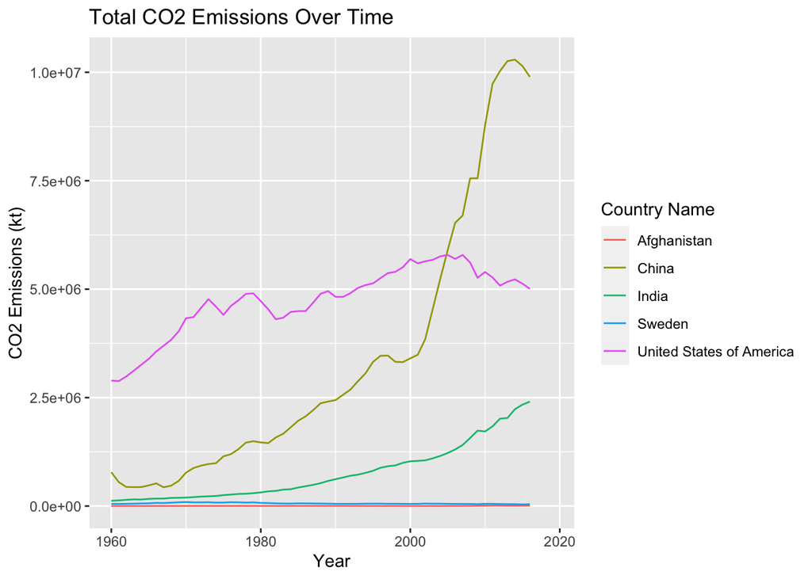

```r
countries <- c("United States of America", "China", "India", "Afghanistan", "Sweden")
selected_countries <- gapminder_data %>%
  filter(name %in% countries)

ggplot(data = selected_countries) +
  geom_line(mapping = aes(x = selected_countries$time,
                          y = selected_countries$co2,
                          color = selected_countries$name)) +
  labs(
    title = "Total CO2 Emissions Over Time",
    x = "Year",
    y = "CO2 Emissions (kt)",
    color = "Country Name"
  )
```

Afghanistan and Sweden have the lowest CO2 emissions, both lines are basically at the 0 mark. The US, China, and India have slowly risen in emissions over the years, with China emitting the most in recent years.

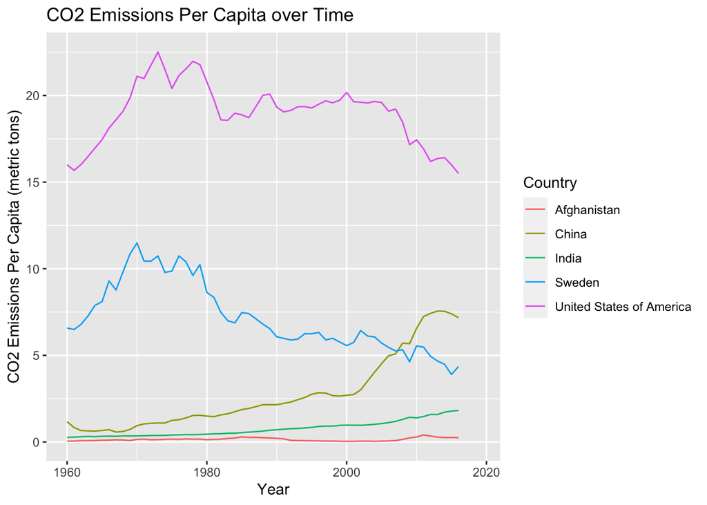

```r
ggplot(data = selected_countries) +
  geom_line(mapping = aes(x = selected_countries$time,
                          y = selected_countries$co2_PC,
                          color = selected_countries$name)) +
  labs(
    title = "CO2 Emissions Per Capita over Time",
    x = "Year",
    y = "CO2 Emissions Per Capita (metric tons)",
    color = "Country"
  )
```

This plot is a bit surprising in comparison to the previous one. Afghanistan still has the least amount of CO2 emissions, but this time India is accompanying Afghanistan along the x axis of the plot. The US has the most metric tons of CO2 emissions per capita, far above any of the other countries.

```r
avg_co2 <- gapminder_data %>%
  group_by(region, time, .groups="rowwise") %>%
  summarize(
    avg_co2_pc = mean(co2_PC, na.rm=TRUE)
  )
```

This code chunk produced a new data frame that is grouped by the region and time columns in the original data frame. I added an additional column with the average CO2 emissions per capita for each region, per year.

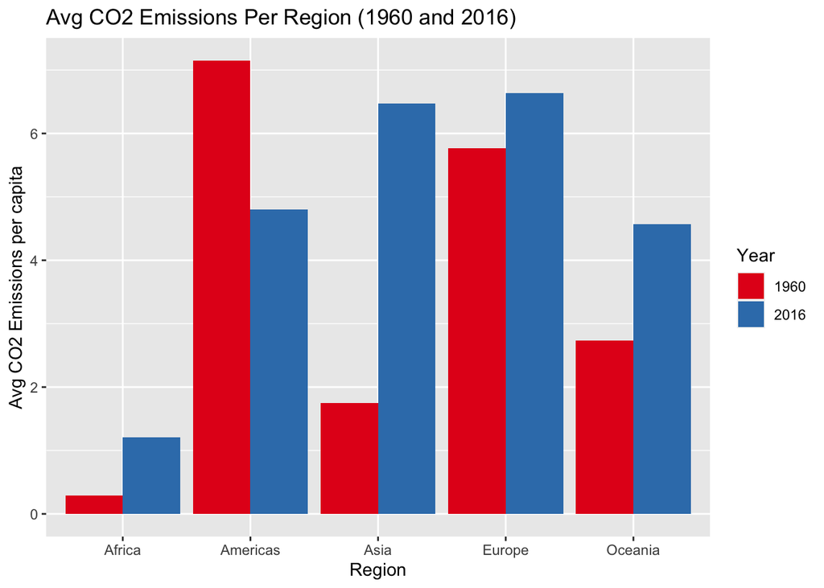

```r
time_filter <- c("1960", "2016")
avg_co2 <- na.omit(avg_co2)%>%
  filter(time %in% c("1960", "2016"))

ggplot(avg_co2, aes(avg_co2$region, avg_co2$avg_co2_pc,
                    fill=as.factor(avg_co2$time)))+
  geom_bar(stat="identity", position="dodge") +
  labs(
    title = "Avg CO2 Emissions Per Region (1960 and 2016)",
    x = "Region",
    y = "Avg CO2 Emissions per capita") +
  scale_fill_manual(
    values = c("#e41a1d", "#377eb9"),
    name="Year"
  )
```

The code chunk above produces a barplot that visualizes the average CO2 emissions per capita in each unique region from the original dataset for the years: 1960, 2016.

group original df by region and time

```r
checking <- gapminder_data %>%
  group_by(time, co2_PC) %>%
  filter(time==2019)

CO2_2016 <- gapminder_data %>%
  drop_na(co2_PC) %>%
  filter(time==2016) %>%
  group_by(region, time, name, .groups="rowwise") %>%
  summarize(avg_co2_pc = mean(co2_PC))
largest_emitters <- CO2_2016 %>%
  group_by(region) %>%
  arrange(desc(avg_co2_pc)) %>%
  slice(1:3) %>%
  select(region, name, avg_co2_pc)

smallest_emitters <- CO2_2016 %>%
  group_by(region) %>%
  arrange(avg_co2_pc) %>%
  slice(1:3) %>%
  select(region, name, avg_co2_pc)
```

Because 2019 is missing data for the co2_PC variable, I did this problem using 2016 stats. The largest CO2 emitters per region are South Africa, Libya, Seychelles, Trinidad and Tobago, United States of America, Canada, Qatar, Kuwait, Bahrain, Gibraltar, Luxembourg, Faroe Islands, New Caledonia, Australia, Palau, NA. The smallest CO2 emiiters per region are Congo, Democratic Republic of the, Somalia, Burundi, Haiti, Nicaragua, Honduras, Afghanistan, Nepal, Yemen, Liechtenstein, Albania, Moldova, Republic of, Solomon Islands, Vanuatu, Kiribati, NA.

### GDP Per Capita

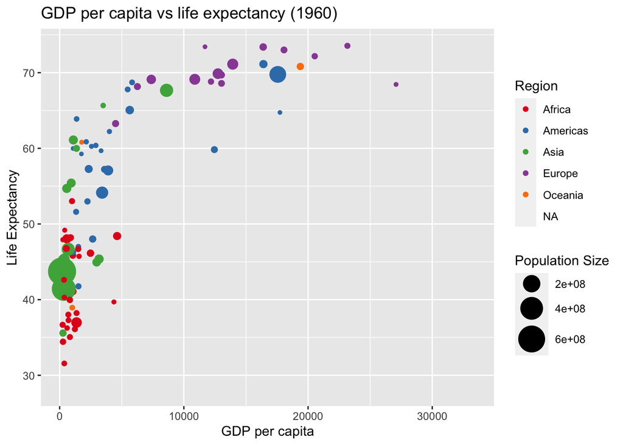

```r
GDP_1960 <- gapminder_data %>%
  filter(time==1960)

ggplot(GDP_1960,
       aes(GDP_1960$GDP_PC, GDP_1960$lifeExpectancy,
           size = GDP_1960$totalPopulation,
           color = GDP_1960$region)) +
  geom_point() +
  labs(
    x = "GDP per capita",
    y = "Life Expectancy",
    title = "GDP per capita vs life expectancy (1960)") +
  scale_color_brewer(palette = "Set1", name = "Region") +
  scale_size_continuous(range = c(1, 10), name = "Population Size")
```

Based on this plot, it looks like Africa and Asia have both the lowest GDP per capita and are on the lower end of the life expectancy spectrum. Europe comes up on top for life expectancy and GDP. The Americas and Oceania are in the middle of the two extremes.

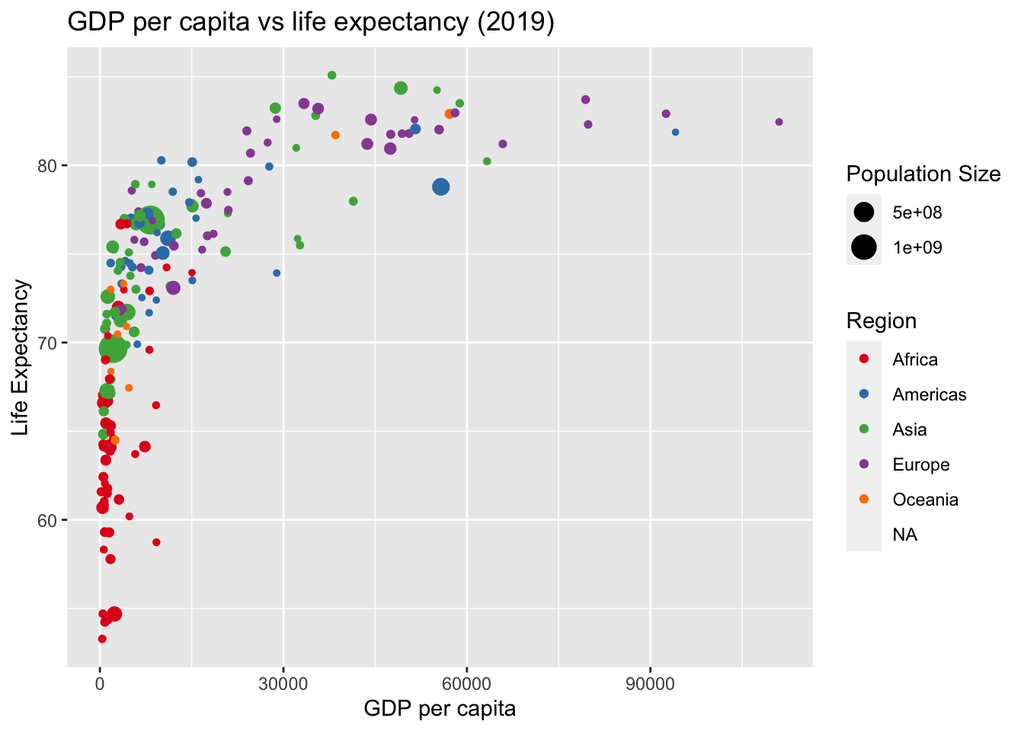

```r
GDP_2019 <- gapminder_data %>%
  filter(time==2019)

ggplot(GDP_2019,
       aes(GDP_2019$GDP_PC, GDP_2019$lifeExpectancy,
           size = GDP_2019$totalPopulation,
           color = GDP_2019$region)) +
  geom_point() +
  labs(
    x = "GDP per capita",
    y = "Life Expectancy",
    title = "GDP per capita vs life expectancy (2019)") +
  scale_color_brewer(palette = "Set1", name = "Region") +
  scale_size_continuous(name = "Population Size")
```

```r
time_filter <- c("1960", "2019")
avg_LE <- gapminder_data %>%
  filter(time %in% time_filter) %>%
  group_by(region, time, .groups="rowwise") %>%
  summarize(avg_LE = mean(lifeExpectancy, na.rm=TRUE))
head(avg_LE)
```

```
## # A tibble: 6 × 4
## # Groups:   region, time [6]
##   region    time .groups avg_LE
##   <chr>    <dbl> <chr>    <dbl>
## 1 Africa    1960 rowwise   41.5
## 2 Africa    2019 rowwise   64.1
## 3 Americas  1960 rowwise   58.6
## 4 Americas  2019 rowwise   75.8
## 5 Asia      1960 rowwise   51.6
## 6 Asia      2019 rowwise   74.6
```

I included the first few rows from my new dataframe displaying the average life expectancy for each region for the years 1960 and 2019. The results do match the figures. For example, in 2019, Africa’s average life expectancy is about 64 years and in the 2019 GDP plot, the center of the Africa points is right around the 64 or 65 year mark.

```r
LE_growth <- gapminder_data %>%
  filter(time %in% time_filter) %>%
  drop_na(lifeExpectancy)%>%
  group_by(region) %>%
  summarize(avg_le_growth = mean(lifeExpectancy[time == 2019] -
                                   lifeExpectancy[time == 1960]))
LE_growth %>%
  arrange(avg_le_growth)
```

```
## # A tibble: 6 × 2
##   region   avg_le_growth
##   <chr>            <dbl>
## 1 <NA>              7.05
## 2 Europe           11.2
## 3 Americas         16.8
## 4 Oceania          17.1
## 5 Africa           22.7
## 6 Asia             23.4
```

Europe has had the smallest amount of growth in life expectancy from 1960 to 2019 and Asia had the highest amount of average growth between the two years.

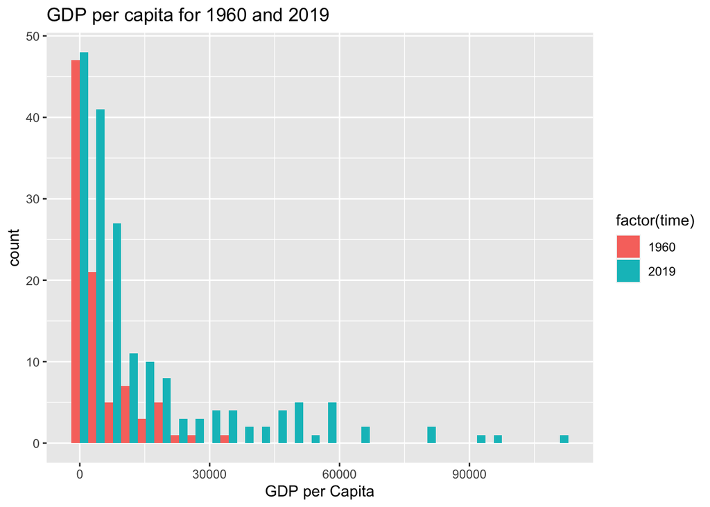

```r
gdp_hist <- gapminder_data %>%
  filter(time %in% time_filter) %>%
  drop_na(GDP_PC) %>%
  select(time, GDP_PC)

ggplot(data = gdp_hist) +
  geom_histogram(aes(x = gdp_hist$GDP_PC, fill=factor(time)),
                 position = "dodge") +
  labs(x = "GDP per Capita",
       title = "GDP per capita for 1960 and 2019"
  )
```

```r
US_rank <- gapminder_data %>%
  filter(time %in% time_filter) %>%
  select(name, time, lifeExpectancy) %>%
  arrange(desc(lifeExpectancy))

le_rank_1960 <- US_rank %>%
  filter(time==1960) %>%
  drop_na(name) %>%
  #arrange(desc(lifeExpectancy))
  mutate(ranking = rank(desc(lifeExpectancy)))

le_rank_2019 <- US_rank %>%
  filter(time==2019) %>%
  drop_na(name) %>%
  mutate(ranking = rank(desc(lifeExpectancy)))
```

The ranking of the U.S. in terms of life expectancy in 1960 was 17 and in 2019 it was 46.

```r
num_countries <- gapminder_data %>%
  filter(!is.na(lifeExpectancy)) %>%
  group_by(time) %>%
  summarize(n = n())

yearly_rank <- gapminder_data %>%
  filter(!is.na(lifeExpectancy)) %>%
  filter(!is.na(name)) %>%
  group_by(time) %>%
  mutate(ranking = rank(desc(lifeExpectancy))) %>%
  filter(name == "United States of America") %>%
  select(time, ranking)

relative_rank <- num_countries %>%
  left_join(yearly_rank, by = "time") %>%
  mutate(relative_rank = ranking / n)

head(relative_rank)
```

```
## # A tibble: 6 × 4
##    time     n ranking relative_rank
##   <dbl> <int>   <dbl>         <dbl>
## 1  1960   189      17        0.0899
## 2  1961   190      14        0.0737
## 3  1962   190      17        0.0895
## 4  1963   189      20        0.106
## 5  1964   189      22        0.116
## 6  1965   190      21        0.111
```

I spent about 12 hours on this problem set!